# Project Business Statistics: E-news Express

## 2. Is the conversion rate (the proportion of users who visit the landing page and get converted) for the new page greater than the conversion rate for the old page?

### Visual Analysis

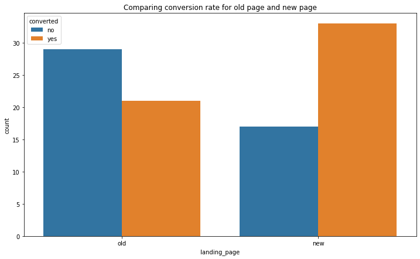

```python
plt.figure(figsize=(12,7)); #display the graph with the given size specifiations for the x-axis and y-axis respectively.
plt.title('Comparing conversion rate for old page and new page'); #insert title for bar graph
sns.countplot(data = df, x = 'landing_page', hue = 'converted'); # display a bar graph for the information
```

Observation:

- There were more subscribers in the new page compared to the old page.
- Conversely, the number of users that did not subscribe on the old page is greater than the new page's.

We will test this analysis further to learn more.

### Step 1 : Define the null and alternate hypothesis for the problem

Let p1, p2 be the proportions for the conversion rate of the new page and the old page respectively.

Null Hypothesis $H_0$ : p1 = p2

Alternate Hypothesis $H_a$ : p1 > p2

### Step 2 : Select appropriate test

- Binomally distributed population - Auser either subscribed or did not subscribe.
- Random sampling from the population - The details from the experiment state that the users were randomly selected.
- The populations are independent of each other.
- To approximate normal distribution we check if both np and n(1-p) are greater than or equal to 10 where n is the sample size and p is the sample proportion respectively. This computation will make the two proportions z-test suitable for this analysis.

#### Approximating normal distribution

```python
#proportion of users that subscribed to the new landing page
p_new = df_new[df_new['converted'] == 'yes']['landing_page'].value_counts()
print('The number of users that subscribed on the new landing page is:', p_new[0])

#proportion of users that subscribed to the old landing page
p_old = df_old[df_old['converted'] == 'yes']['landing_page'].value_counts()
print('The total number of users that subscribed to the old landing page is:',p_old[0])
```

```
The number of users that subscribed on the new landing page is: 33
The total number of users that subscribed to the old landing page is: 21
```

```python
#Compute np1 and n(1-p) respectively, for new and old page
x_new = df_new.shape[0] * (p_new / df_new.shape[0]) #this follows the formula np1
print('The value of np1 for new page is:',x_new[0])

y_new = df_new.shape[0] - x_new #follows the formula n(1-p1) which is simplified as (n - np1)
print('The value of n(1-p1) for new page is:', y_new[0])

x_old = df_old.shape[0] * (p_old / df_old.shape[0]) #this follows the formula np1
print('The value of np1 for old page is:', x_old[0])

y_old = df_old.shape[0] - x_old #follows the formula n(1-p1) which is simplified as (n - np1)
print('The value of n(1-p1) for old page is:', y_old[0])
```

```
The value of np1 for new page is: 33.0
The value of n(1-p1) for new page is: 17.0
The value of np1 for old page is: 21.0
The value of n(1-p1) for old page is: 29.0
```

```python
#verify approximation values
test_list = [x_new, y_new, x_old, y_old]
for i in test_list:
    if i[0] >= 10 :
        print('The approximation meets the criteria!')
    else :
        print('The approximation does not meet the criteria!')
```

```
The approximation meets the criteria!
The approximation meets the criteria!
The approximation meets the criteria!
The approximation meets the criteria!
```

#### Since all values are greater than or equal to 10, we can approximate normal distribution for the binomial distribution and use the two proportions z-test.

### Step 3: Define Significance Level

As given in the project description, we select $\alpha = 0.05$.

### Step 4: Collect and prepare data

```python
#proportion of users that subscribed to the new landing page
p_new = df_new[df_new['converted'] == 'yes']['landing_page'].value_counts()

#proportion of users that subscribed to the old landing page
p_old = df_old[df_old['converted'] == 'yes']['landing_page'].value_counts()

#total number of users in the treatment group or new landing page
treat_users = df_new.shape[0]

#total number of users in the control group or old landing page
control_users = df_old.shape[0]
```

```python
print('The proportion of users that converted from the new and old landing pages are', p_new[0] / treat_users, 'and', p_old[0] / control_users, 'respectively.')
```

```
The proportion of users that converted from the new and old landing pages are 0.66 and 0.42 respectively.
```

### Step 5: Compute p-value

```python
from statsmodels.stats.proportion import proportions_ztest #import required function

test_stat, p_value = proportions_ztest([p_new[0], p_old[0]], [treat_users, control_users], alternative = 'larger')

print('The p-value is', p_value)
```

```
The p-value is 0.008026308204056278
```

### Step 6: Compare the p-value with $\alpha$

```python
# print the conclusion based on p-value
if p_value < 0.05:
    print(f'As the p-value {p_value} is less than the level of significance, we reject the null hypothesis.')
else:
    print(f'As the p-value {p_value} is greater than the level of significance, we fail to reject the null hypothesis.')
```

```
As the p-value 0.008026308204056278 is less than the level of significance, we reject the null hypothesis.
```

### Step 7: Inference

As the p-value (~0.008) is less than the value of $\alpha$ (0.05) we can reject the null hypothesis. This follows the principle that if null is low, null must go. Hence, we have enough statistical evidence to show that the conversion rate for the new page is greater than the one of the old page.

## 3. Is the conversion and preferred language are independent or related?

### Visual Analysis

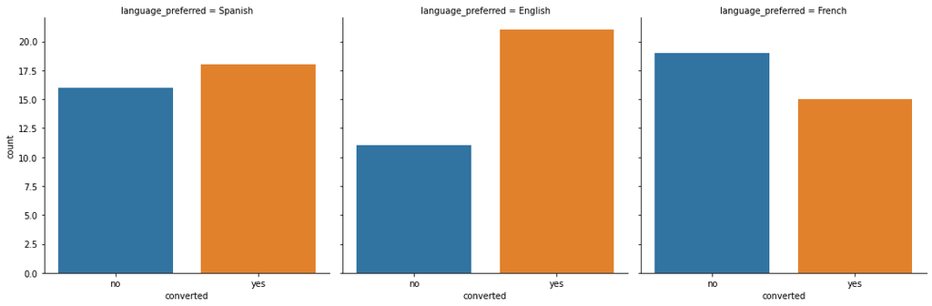

```python
plt.figure(figsize=(12,7)); #display the graph with the given size specifiations for the x-axis and y-axis respectively.
sns.catplot(data = df, x = 'converted', col = 'language_preferred', kind = 'count');
plt.show();
```

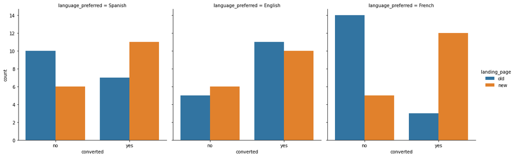

```python
plt.figure(figsize=(12,7)); #display the graph with the given size specifiations for the x-axis and y-axis respectively.
sns.catplot(data = df, x = 'converted', col = 'language_preferred', kind = 'count', hue = 'landing_page');
plt.show();
```

Observation:

We will test this analysis further to learn more.

### Step 1: Define the null and alternate hypotheses

Null Hypothesis: $H_0:$ The converted status is independent of the preferred language.

Alternative Hypothesis: $H_a:$ The converted status depends on the preferred language.

### Step 2: Selecting appropriate test

The above problem fits the Chi-square test of independence as it meets the following requirements:

- Two categorical variables - converted and language preferred.
- The expected value of the number of sample observations in each level of the observations is more than 5.
- The samples were randomly selected from the population.

### Step 3: Define Significance level

As given in the project descriptiont, we select α = 0.05.

### Step 4: Collect and prepare data

```python
#create dataframe with the two categorical variables
df_cont = df.drop(['group','user_id','time_spent_on_the_page','landing_page'], axis = 1)
df_cont.head()
```

|  | converted | language_preferred |
| --- | --- | --- |
| 0 | no | Spanish |
| 1 | yes | English |
| 2 | no | Spanish |
| 3 | no | French |
| 4 | yes | Spanish |

```python
#create contingency table containing the two categorical variables
contingency_table = pd.crosstab(df_cont['converted'], df_cont['language_preferred'])
contingency_table
```

| language_preferred converted | English | French | Spanish |
| --- | --- | --- | --- |
| no | 11 | 19 | 16 |
| yes | 21 | 15 | 18 |

### Step 5: Compute p-value

#### The chi2_contingency will be used to compute the p-value for this test.

```python
from scipy.stats import chi2_contingency #import required function

chi2, p_value, dof, exp_freq = chi2_contingency(contingency_table) #computing for p-value

print('The p-value is', p_value)
```

```
The p-value is 0.21298887487543447
```

### Step 6: Compare p-value with $\alpha$

```python
# print the conclusion based on p-value
if p_value < 0.05:
    print(f'As the p-value {p_value} is less than the level of significance, we reject the null hypothesis.')
else:
    print(f'As the p-value {p_value} is greater than the level of significance, we fail to reject the null hypothesis.')
```

```
As the p-value 0.21298887487543447 is greater than the level of significance, we fail to reject the null hypothesis.
```

### Step 7: Inference

As the p-value (~0.213) is greater than the value of $\alpha$ (0.05) we fail to reject the null hypothesis. This follows the principle that if null is high, null must fly. Hence, we do not have enough statistical evidence to show that the converted status depends on the preferred language.

## 4. Is the time spent on the new page same for the different language users?

### Visual Analysis

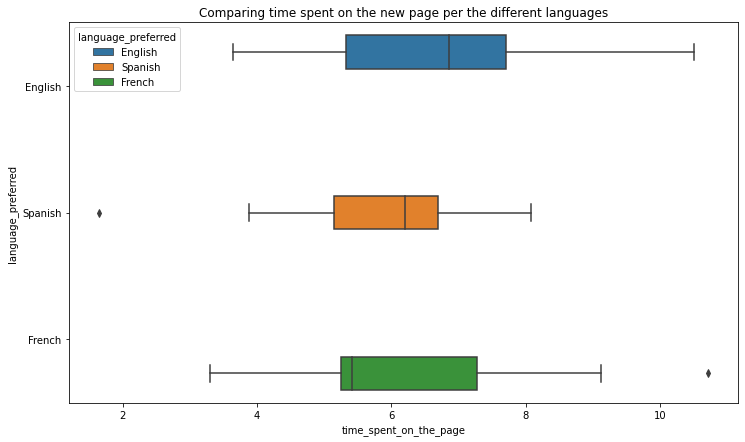

```python
plt.figure(figsize = (12,7));  #display the graph with the given size specifiations for the x-axis and y-axis respectively.

plt.title('Comparing time spent on the new page per the different languages'); #insert title for bar graph

#create boxplot for the different preferred languages
sns.boxplot(data = df_new, x = 'time_spent_on_the_page', y = 'language_preferred', hue = 'language_preferred');
```

We will test this analysis further to learn more.

### Step 1: Define the null and alternative hypotheses

Let Let $\mu_1, \mu_2, \mu_3$ be the average time spent on the new page for English, Spanish and French respectively.

Null hypothesis: The mean time spent on the new page for all three language users are the equal.

$H_0:$ $\mu_1 = \mu_2 = \mu_3$

Alternative hypothesis: $H_a: $ At least one of the mean times spent on the new page is different from the other preferred languages.

### Step 2: Select appropriate test

The normality and equality of variances assumptions need to be checked.  
We will verify this with the Shapiro-Wilk's test and the Levene's test using the shapiro() function and levene() function respectively to compute the test statistic and p-value.

#### 1. Shapiro-Wilk's Test

We will test the null hypothesis

> $H_0:$ Time soent on new page follows a normal distribution against

against the alternative hypothesis

> $H_a:$ Time spent on new page does not follow a normal distribution

```python
#Normality test
# import the required function
from scipy import stats

# compute the p-value
w, p_value = stats.shapiro(df_new['time_spent_on_the_page'])

print('The p-value is', p_value)

if p_value < 0.05:
    print(f'As the p-value {p_value} is less than the level of significance, we reject the null hypothesis.')
else:
    print(f'As the p-value {p_value} is greater than the level of significance, we fail to reject the null hypothesis.')
```

```
The p-value is 0.8040016293525696
As the p-value 0.8040016293525696 is greater than the level of significance, we fail to reject the null hypothesis.
```

#### 2. Levene's Test

We will test the null hypothesis

> $H_0$: All the population variances are equal

against the alternative hypothesis

> $H_a$: At least one variance is different from the rest

```python
#Homogeneity of Variance test
#import the required function
from scipy.stats import levene
statistic, p_value = levene( df_new['time_spent_on_the_page'][df_new['language_preferred'] == "English"],
                                   df_new['time_spent_on_the_page'][df_new['language_preferred'] == "Spanish"],
                                   df_new['time_spent_on_the_page'][df_new['language_preferred'] == "French"])
# find the p-value
print('The p-value is', p_value)

if p_value < 0.05:
    print(f'As the p-value {p_value} is less than the level of significance, we reject the null hypothesis.')
else:
    print(f'As the p-value {p_value} is greater than the level of significance, we fail to reject the null hypothesis.')
```

```
The p-value is 0.46711357711340173
As the p-value 0.46711357711340173 is greater than the level of significance, we fail to reject the null hypothesis.
```

The computations satisfy the following asumptions:

- The populations are normally distributed as verified by the Shapiro-Wilk’s test.
- Samples are independent simple random samples as stated in the problem statement.
- Population variances are equal as verified by the Levene's test.

### Step 3: Define significance level.

We consider the significance level to be 0.05 as stated in the problem statement.

### Step 4: Collect and prepare data.

```python
#Subset the dataframe to obtain different columns for different languages
df_english = df_new['time_spent_on_the_page'][df_new['language_preferred'] == "English"]
df_spanish = df_new['time_spent_on_the_page'][df_new['language_preferred'] == "Spanish"]
df_french =  df_new['time_spent_on_the_page'][df_new['language_preferred'] == "French"]
```

### Step 5: Compute p-value

```python
#import the required function
from scipy.stats import f_oneway

# perform one-way anova test
test_stat, p_value = f_oneway(df_english, df_spanish, df_french)
print('The p-value is ' + str(p_value))
```

```
The p-value is 0.43204138694325955
```

### Step 6: Compare p-value with significance level

```python
# print the conclusion based on p-value
if p_value < 0.05:
    print(f'As the p-value {p_value} is less than the level of significance, we reject the null hypothesis.')
else:
    print(f'As the p-value {p_value} is greater than the level of significance, we fail to reject the null hypothesis.')
```

```
As the p-value 0.43204138694325955 is greater than the level of significance, we fail to reject the null hypothesis.
```

### Step 7: Inference

As the p-value (~0.432) is greater than the value of $\alpha$ (0.05) we fail to reject the null hypothesis.  
This follows the principle that if null is high, null must fly. Hence, we do not have enough statistical evidence to show that at least one of the mean times spent on the new page per the preferred language is different from the others.

## Conclusion and Business Recommendations

### Recommendations:

- Other languages could be installed on the online platform to create a more diverse platform and consequently attract people who speak other languages.
- The french group showed a high preference for the new page. Further query could be done to understand these preferences and possibly implement some of these ideas on the English and Spanish pages.
- The website should be scraped of external advertisements, if any, that may distract users and reduce the activity or the time spent on the page.
- The use of video or audio files could be used on the website to allow users assimilate more information quicker as reading could be relatively tedious and possibly deter users from spending time on the website.
- Further analysis could be done to investigate the influence of subscription charges, if any, on users as it could also influence conversion rate.
- A comment section could be included on the platform to allow users share reviews and help to streamline any future improvements that may need to be done.